# Test Exercise 1

### (c) It seems there are two sets of observations in the scatter diagram, one for clients aged 40 or higher and another for clients aged below 40. Divide the sample into these two clusters, and for each cluster estimate the coefficients a and b and determine the standard error and t-value of b

```python
below40 <- data[data$Age < 40, ]
fit1 <- lm(Expenditure ~ Age,data=below40)

sprintf("Regression values (for clients below age 40):")
sprintf("a = %.2f", coef(fit1)[1])
sprintf("b = %.2f", coef(fit1)[2])
sprintf("standard-error = %.2f", summary(fit1)$sigma)
sprintf("t-value of b = %.5f", coef(summary(fit1))[2, "t value"])
```

'Regression values (for clients below age 40):'

'a = 100.23'

'b = 0.20'

'standard-error = 1.15'

't-value of b = 4.46045'

```python
above40 <- data[data$Age >= 40, ]
fit2 <- lm(Expenditure ~ Age,data=above40)

sprintf("Regression values (for clients above age 40):")
sprintf("a = %.2f", coef(fit2)[1])
sprintf("b = %.2f", coef(fit2)[2])
sprintf("standard-error = %.2f", summary(fit2)$sigma)
sprintf("t-value of b = %.5f", coef(summary(fit2))[2, "t value"])
```

'Regression values (for clients above age 40):'

'a = 88.87'

'b = 0.15'

'standard-error = 3.83'

't-value of b = 0.74206'

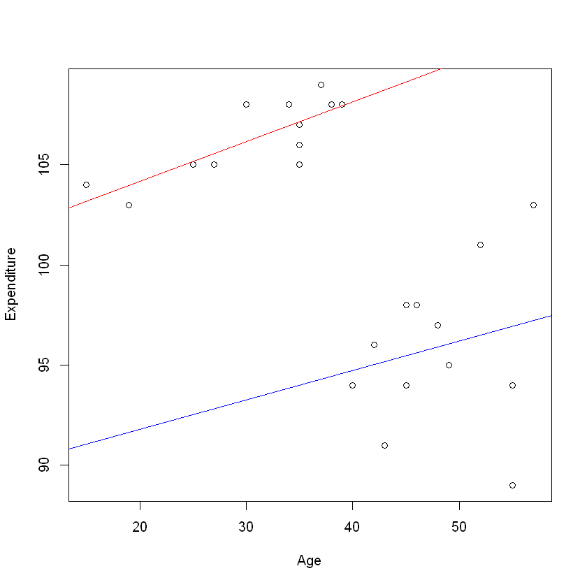

```python
plot(data$Age, data$Expenditure, xlab="Age", ylab="Expenditure")
abline(fit1, col="red")
abline(fit2, col="blue")
```

### d) Discuss and explain the main differences between the outcomes in parts (a) and (c). Describe in words what you have learned from these results.

In part (a) we fit the all the observations into a single linear regression line. In part (c), we split the observations into two groups and fit a linear regression to each group separately. The result in (c) provides a much better fit for each group.